# Effect of labels on categoricality and alignment

Gary Lupyan, Ellise Suffill

2023-12-19

# Study 1

```r
indiv_df_1 <- read.csv(file="data/CEL_1_indiv_data.tsv", header=T, sep="\t") %>%
    mutate(Condition = case_when(
        cond_numeric<0 ~ "Baseline",
        cond_numeric==0 ~ "No Labels",
        cond_numeric>0 ~ "With Labels"),
        exp = "exp1")

pairwise_df_1 <- read.csv(file="data/CEL_1_pairwise_data.tsv", header=T, sep="\t")

#get alignment between pairs of participants for within category comparisons
pairwise_df_1_within <- read.csv(file="data/CEL_1_pairwise_within.tsv", header=T, sep="\t") %>%
    select(participant_a, participant_b, z_transformed_rank_r) %>%
    rename(mean_alignment_within = z_transformed_rank_r)

#get alignment between pairs of participants for between category comparisons
pairwise_df_1_between <- read.csv(file="data/CEL_1_pairwise_cross.tsv", header=T, sep="\t") %>%
    select(participant_a, participant_b, z_transformed_rank_r) %>%
    rename(mean_alignment_between = z_transformed_rank_r)

pairwise_df_1 <- left_join(pairwise_df_1,pairwise_df_1_within,
                                                     by=c("participant_a"="participant_a", "participant_b"="participant_b"))

pairwise_df_1 <- left_join(pairwise_df_1,pairwise_df_1_between,
                                                     by=c("participant_a"="participant_a", "participant_b"="participant_b"))
```

## Effect of condition on categoricality as log(between/within)

```r
indiv_df_1 %>% group_by(Condition) %>%
    summarize(categoricality = mean(log_cat_ratio), sd=sd(log_cat_ratio))
```

```
## # A tibble: 3 × 3
##   Condition   categoricality    sd
##   <chr>                <dbl> <dbl>
## 1 Baseline             0.375 0.557
## 2 No Labels            0.395 0.402
## 3 With Labels          0.653 0.700
```

Categoricality significantly higher in sorts from with labels condition, compared with no labels and baseline conditions.

```r
no_labels_vs_all <- lm(formula=log_cat_ratio ~ relevel(as.factor(cond_numeric), ref='1'), data=indiv_df_1)
baseline_vs_all <- lm(formula=log_cat_ratio ~ relevel(as.factor(cond_numeric), ref='-1'), data=indiv_df_1)
summary(no_labels_vs_all)
```

```
##
## Call:
## lm(formula = log_cat_ratio ~ relevel(as.factor(cond_numeric),
##     ref = "1"), data = indiv_df_1)
##
## Residuals:
##      Min       1Q   Median       3Q      Max
## -0.74148 -0.30171 -0.15304  0.08274  3.07065
##
## Coefficients:
##                                               Estimate Std. Error t value
## (Intercept)                                    0.65280    0.08807   7.412
## relevel(as.factor(cond_numeric), ref = "1")-1 -0.27778    0.12175  -2.282
## relevel(as.factor(cond_numeric), ref = "1")0  -0.25756    0.12309  -2.092
##                                               Pr(>|t|)
## (Intercept)                                   1.59e-11 ***
## relevel(as.factor(cond_numeric), ref = "1")-1   0.0242 *
## relevel(as.factor(cond_numeric), ref = "1")0    0.0384 *
## ---
## Signif. codes:  0 '***' 0.001 '**' 0.01 '*' 0.05 '.' 0.1 ' ' 1
##
## Residual standard error: 0.5639 on 126 degrees of freedom
## Multiple R-squared:  0.04791,    Adjusted R-squared:  0.0328
## F-statistic:  3.17 on 2 and 126 DF,  p-value: 0.04536
```

```r
summary(baseline_vs_all)
```

```
##
## Call:
## lm(formula = log_cat_ratio ~ relevel(as.factor(cond_numeric),
##     ref = "-1"), data = indiv_df_1)
##
## Residuals:
##      Min       1Q   Median       3Q      Max
## -0.74148 -0.30171 -0.15304  0.08274  3.07065
##
## Coefficients:
##                                               Estimate Std. Error t value
## (Intercept)                                    0.37502    0.08406   4.461
## relevel(as.factor(cond_numeric), ref = "-1")0  0.02021    0.12026   0.168
## relevel(as.factor(cond_numeric), ref = "-1")1  0.27778    0.12175   2.282
##                                               Pr(>|t|)
## (Intercept)                                   1.78e-05 ***
## relevel(as.factor(cond_numeric), ref = "-1")0   0.8668
## relevel(as.factor(cond_numeric), ref = "-1")1   0.0242 *
## ---
## Signif. codes:  0 '***' 0.001 '**' 0.01 '*' 0.05 '.' 0.1 ' ' 1
##
## Residual standard error: 0.5639 on 126 degrees of freedom
## Multiple R-squared:  0.04791,    Adjusted R-squared:  0.0328
## F-statistic:  3.17 on 2 and 126 DF,  p-value: 0.04536
```

### Categoricality figure - violin

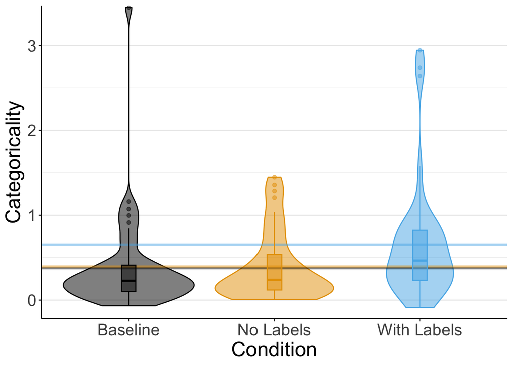

```r
means <- indiv_df_1 %>%
  group_by(Condition) %>%
  summarise(Categoricality = mean(log_cat_ratio))

ggplot(indiv_df_1, aes(y=log_cat_ratio, x=Condition, color=Condition, fill=Condition)) +
  geom_violin(alpha=.5) +
    scale_color_manual(values= colors) +
  scale_fill_manual(values= colors) +
  geom_hline(data=means, aes(yintercept=Categoricality, color=Condition), alpha=.5, size=1) +
  geom_boxplot(width=0.1, alpha=.5) +
  theme_bw() +
  ylab("Categoricality") +
  theme(text=element_text(size=20)) +
    coord_cartesian(ylim=c(-.05,3.3))+
  theme(legend.position="blank") +
  theme(panel.grid.major.x = element_blank(), panel.grid.minor.x = element_blank()) +
  theme(panel.border = element_blank(), axis.line = element_line())
```

```r
ggsave("plots/CEL_1_categoricality_violin.pdf")
```

## Effect of condition on the number of clusters formed during free sort

Label participants produce sorts with significantly fewer clusters

```r
indiv_df_1 %>% group_by(Condition) %>% summarize(num_clusters =round(mean(n_clusters),1))
```

```
## # A tibble: 3 × 2
##   Condition   num_clusters
##   <chr>              <dbl>
## 1 Baseline             3.9
## 2 No Labels            4.1
## 3 With Labels          3.1
```

Poisson model (shown by likelihood ratio test to be nearly identical to the negative binomial model)

```r
nb_counts <- indiv_df_1 %>% MASS::glm.nb(formula=n_clusters ~ relevel(as.factor(cond_numeric), ref='1'), data=.)
poisson_counts <- indiv_df_1 %>% glm(formula=n_clusters ~ relevel(as.factor(cond_numeric), ref='1'), data=.,family=poisson)
pchisq(2 * (logLik(nb_counts) - logLik(poisson_counts)), df = 1, lower.tail = FALSE)
```

```
## 'log Lik.' 1 (df=4)
```

```r
summary(poisson_counts)
```

```
##
## Call:
## glm(formula = n_clusters ~ relevel(as.factor(cond_numeric), ref = "1"),
##     family = poisson, data = .)
##
## Coefficients:
##                                               Estimate Std. Error z value
## (Intercept)                                    1.13062    0.08874  12.741
## relevel(as.factor(cond_numeric), ref = "1")-1  0.23887    0.11629   2.054
## relevel(as.factor(cond_numeric), ref = "1")0   0.27297    0.11657   2.342
##                                               Pr(>|z|)
## (Intercept)                                     <2e-16 ***
## relevel(as.factor(cond_numeric), ref = "1")-1   0.0400 *
## relevel(as.factor(cond_numeric), ref = "1")0    0.0192 *
## ---
## Signif. codes:  0 '***' 0.001 '**' 0.01 '*' 0.05 '.' 0.1 ' ' 1
##
## (Dispersion parameter for poisson family taken to be 1)
##
##     Null deviance: 99.535  on 128  degrees of freedom
## Residual deviance: 93.094  on 126  degrees of freedom
## AIC: 499.01
##
## Number of Fisher Scoring iterations: 4
```

```r
prop_2_cluster_sort <- indiv_df_1 %>%
  group_by(cond_numeric) %>%
  summarise(n_clusters = mean(n_clusters==2))
prop_2_cluster_sort
```

```
## # A tibble: 3 × 2
##   cond_numeric n_clusters
##          <int>      <dbl>
## 1           -1      0.2
## 2            0      0.326
## 3            1      0.537
```

```r
m1 <- glm(I(n_clusters==2) ~ relevel(as.factor(cond_numeric), ref='1'), data=indiv_df_1,family=binomial)
summary(m1)
```

```
##
## Call:
## glm(formula = I(n_clusters == 2) ~ relevel(as.factor(cond_numeric),
##     ref = "1"), family = binomial, data = indiv_df_1)
##
## Coefficients:
##                                               Estimate Std. Error z value
## (Intercept)                                     0.1466     0.3132   0.468
## relevel(as.factor(cond_numeric), ref = "1")-1  -1.5329     0.4868  -3.149
## relevel(as.factor(cond_numeric), ref = "1")0   -0.8748     0.4517  -1.937
##                                               Pr(>|z|)
## (Intercept)                                    0.63971
## relevel(as.factor(cond_numeric), ref = "1")-1  0.00164 **
## relevel(as.factor(cond_numeric), ref = "1")0   0.05275 .
## ---
## Signif. codes:  0 '***' 0.001 '**' 0.01 '*' 0.05 '.' 0.1 ' ' 1
##
## (Dispersion parameter for binomial family taken to be 1)
##
##     Null deviance: 166.85  on 128  degrees of freedom
## Residual deviance: 155.92  on 126  degrees of freedom
## AIC: 161.92
##
## Number of Fisher Scoring iterations: 4
```

### Cluster figure

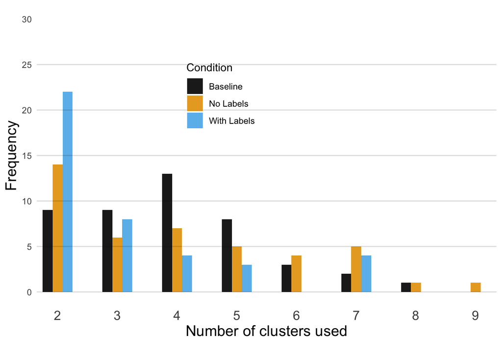

```r
means <- indiv_df_1 %>%
  dplyr::group_by(Condition) %>%
  dplyr::summarise(Clusters = mean(n_clusters))

ggplot(indiv_df_1, aes(x=n_clusters, fill=Condition)) +
  geom_histogram(alpha=0.9,position="dodge", binwidth=0.5)+
    scale_y_continuous(breaks = seq(0, 30, 5))+
  scale_x_continuous(breaks = seq(1, 10, 1.00))+
  labs(caption = "", size=20) +
  theme_minimal() +
  theme(panel.grid.major = element_blank()) +
  theme(panel.grid.minor = element_blank()) +
  geom_hline(yintercept = c(0,5,10,15,20,25), alpha = 0.15) +
  scale_fill_manual(values=colors) +
  scale_color_manual(values=colors) +
  ylab("Frequency") +
  xlab("Number of clusters used") +
    coord_cartesian(ylim=c(0,30),xlim=c(2,9))+
  theme(axis.text.x = element_text(size=13),
       axis.title.y = element_text(size=15),
       axis.title.x = element_text(size=15))+
  theme(legend.position = c(.4, .7))
```

```r
ggsave("plots/CEL_1_n_clusters_histogram.pdf")
```

## Effect of condition on alignment (aggregated by a and b participants in each pair)

Alignment significantly higher in with labels, compared with no labels and baseline

```r
pairwise_df_1 <- pairwise_df_1 %>%
    mutate(cat_min = pmin(cat_diff_log_ratio_a, cat_diff_log_ratio_b),
                 cat_max = pmax(cat_diff_log_ratio_a, cat_diff_log_ratio_b),
                 cat_abs_diff = abs(cat_diff_log_ratio_a-cat_diff_log_ratio_b),
                 cluster_min = pmin(pp_a_n_clusters, pp_b_n_clusters),
                 cluster_max = pmax(pp_a_n_clusters, pp_b_n_clusters),
                 cluster_abs_diff = abs(pp_a_n_clusters-pp_b_n_clusters)
                 )

d_1a <- pairwise_df_1 %>%
  group_by(cond_numeric,Condition,participant_a) %>%
  summarize_if(is.numeric,mean,na.rm=TRUE) %>%
  rename(participant = participant_a)
d_1b <- pairwise_df_1 %>%
  group_by(cond_numeric,Condition,participant_b) %>%
  summarize_if(is.numeric,mean,na.rm=TRUE) %>%
  rename(participant = participant_b)
d_1_all <- rbind(d_1a,d_1b) %>%
  group_by(cond_numeric,Condition,participant) %>%
  summarize_if(is.numeric,mean,na.rm=TRUE) %>%
    rename(mean_alignment = z_transformed_rank_r)

#merge in individual categoricality
d_1_all <- d_1_all %>% left_join(select(indiv_df_1,participant,log_cat_ratio))


#residualize categoricality from alignment for later analysis
d_1_all$mean_alignment_adj <- resid(lm(mean_alignment ~ cat_min, data=d_1_all))
d_1_all$exp <- "exp1"

d_1_all %>% group_by(Condition) %>% summarize(alignment = mean(mean_alignment), sd=(sd(mean_alignment)),n=n())
```

```
## # A tibble: 3 × 4
##   Condition   alignment     sd     n
##   <chr>           <dbl>  <dbl> <int>
## 1 Baseline        0.105 0.0786    45
## 2 No Labels       0.124 0.0748    43
## 3 With Labels     0.201 0.137     41
```

```r
labels_vs_all <- lm(formula=mean_alignment ~ relevel(as.factor(cond_numeric), ref='1'), data=d_1_all)
baseline_vs_all <- lm(formula=mean_alignment ~ relevel(as.factor(cond_numeric), ref='-1'), data=d_1_all)

summary(labels_vs_all)
```

```
##
## Call:
## lm(formula = mean_alignment ~ relevel(as.factor(cond_numeric),
##     ref = "1"), data = d_1_all)
##
## Residuals:
##      Min       1Q   Median       3Q      Max
## -0.22289 -0.06849 -0.02223  0.06572  0.36574
##
## Coefficients:
##                                               Estimate Std. Error t value
## (Intercept)                                    0.20114    0.01563  12.869
## relevel(as.factor(cond_numeric), ref = "1")-1 -0.09610    0.02161  -4.447
## relevel(as.factor(cond_numeric), ref = "1")0  -0.07753    0.02185  -3.549
##                                               Pr(>|t|)
## (Intercept)                                    < 2e-16 ***
## relevel(as.factor(cond_numeric), ref = "1")-1 1.89e-05 ***
## relevel(as.factor(cond_numeric), ref = "1")0  0.000545 ***
## ---
## Signif. codes:  0 '***' 0.001 '**' 0.01 '*' 0.05 '.' 0.1 ' ' 1
##
## Residual standard error: 0.1001 on 126 degrees of freedom
## Multiple R-squared:  0.1481, Adjusted R-squared:  0.1346
## F-statistic: 10.95 on 2 and 126 DF,  p-value: 4.121e-05
```

```r
summary(baseline_vs_all)
```

```
##
## Call:
## lm(formula = mean_alignment ~ relevel(as.factor(cond_numeric),
##     ref = "-1"), data = d_1_all)
##
## Residuals:
##      Min       1Q   Median       3Q      Max
## -0.22289 -0.06849 -0.02223  0.06572  0.36574
##
## Coefficients:
##                                               Estimate Std. Error t value
## (Intercept)                                    0.10505    0.01492   7.041
## relevel(as.factor(cond_numeric), ref = "-1")0  0.01857    0.02134   0.870
## relevel(as.factor(cond_numeric), ref = "-1")1  0.09610    0.02161   4.447
##                                               Pr(>|t|)
## (Intercept)                                   1.10e-10 ***
## relevel(as.factor(cond_numeric), ref = "-1")0    0.386
## relevel(as.factor(cond_numeric), ref = "-1")1 1.89e-05 ***
## ---
## Signif. codes:  0 '***' 0.001 '**' 0.01 '*' 0.05 '.' 0.1 ' ' 1
##
## Residual standard error: 0.1001 on 126 degrees of freedom
## Multiple R-squared:  0.1481, Adjusted R-squared:  0.1346
## F-statistic: 10.95 on 2 and 126 DF,  p-value: 4.121e-05
```

### Alignment plot

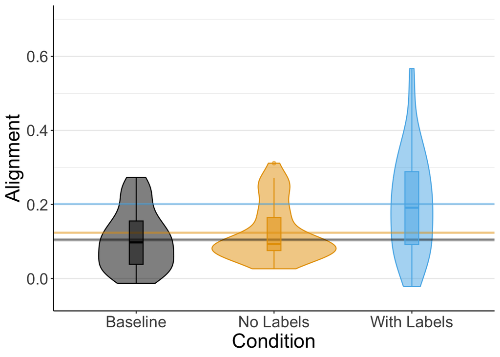

```r
means <- d_1_all %>%
  group_by(Condition) %>%
  summarise(Alignment = mean(mean_alignment))

ggplot(d_1_all, aes(y=mean_alignment, x=Condition, color=Condition, fill=Condition)) +
  geom_violin(alpha=.5) +
  geom_hline(data=means, aes(yintercept=Alignment, col=Condition), alpha=.5, size=1) +
  geom_boxplot(width=0.1, alpha=.5) +
  theme_bw() +
  scale_fill_manual(values=colors) +
  scale_color_manual(values=colors) +
  ylab("Alignment") +
  xlab("Condition") +
  theme(text=element_text(size=20)) +
    coord_cartesian(ylim=c(-.05,.7))+
    theme(legend.position="blank") +
  theme(panel.grid.major.x = element_blank(), panel.grid.minor.x = element_blank()) +
  theme(panel.border = element_blank(), axis.line = element_line())
```

```r
ggsave("plots/CEL_1_alignment_violin.pdf")
```

For supplementary materials (Fig 3S)

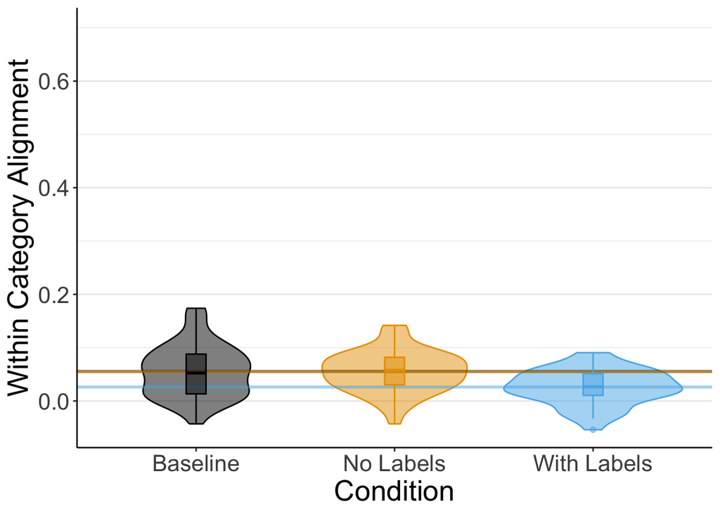

```r
means <- d_1_all %>%
  group_by(Condition) %>%
  summarise(Alignment = mean(mean_alignment_within))

ggplot(d_1_all, aes(y=mean_alignment_within, x=Condition, color=Condition, fill=Condition)) +
  geom_violin(alpha=.5) +
  geom_hline(data=means, aes(yintercept=Alignment, col=Condition), alpha=.5, size=1) +
  geom_boxplot(width=0.1, alpha=.5) +
  theme_bw() +
  scale_fill_manual(values=colors) +
  scale_color_manual(values=colors) +
  ylab("Within Category Alignment") +
  xlab("Condition") +
  theme(text=element_text(size=20)) +
    coord_cartesian(ylim=c(-.05,.7))+
    theme(legend.position="blank") +
  theme(panel.grid.major.x = element_blank(), panel.grid.minor.x = element_blank()) +
  theme(panel.border = element_blank(), axis.line = element_line())
```

```r
ggsave("plots/CEL_1_alignment_within_violin.pdf")
```

For supplementary materials (Fig 3S)

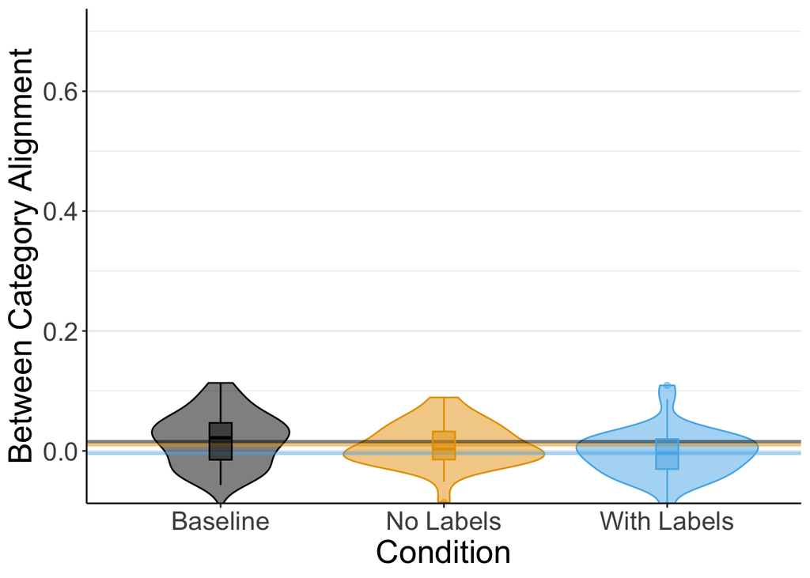

```r
means <- d_1_all %>%
  group_by(Condition) %>%
  summarise(Alignment = mean(mean_alignment_between))

ggplot(d_1_all, aes(y=mean_alignment_between, x=Condition, color=Condition, fill=Condition)) +
  geom_violin(alpha=.5) +
  geom_hline(data=means, aes(yintercept=Alignment, col=Condition), alpha=.5, size=1) +
  geom_boxplot(width=0.1, alpha=.5) +
  theme_bw() +
  scale_fill_manual(values=colors) +
  scale_color_manual(values=colors) +
  ylab("Between Category Alignment") +
  xlab("Condition") +
  theme(text=element_text(size=20)) +
    coord_cartesian(ylim=c(-.05,.7))+
    theme(legend.position="blank") +
  theme(panel.grid.major.x = element_blank(), panel.grid.minor.x = element_blank()) +
  theme(panel.border = element_blank(), axis.line = element_line())
```

```r
ggsave("plots/CEL_1_alignment_between_violin.pdf")
```

## Correlation between alignment and different measures of pair-wise categoricality

Mean alignment most strongly correlated with minimum pairwise categoricality (cat_min)

```r
d_1_all %>% ungroup %>%
    select(mean_alignment,cat_min,cat_max, cat_abs_diff) %>%
    correlate
```

```
## Correlation computed with
## • Method: 'pearson'
## • Missing treated using: 'pairwise.complete.obs'
```

```
## # A tibble: 4 × 5
##   term           mean_alignment cat_min cat_max cat_abs_diff
##   <chr>                   <dbl>   <dbl>   <dbl>        <dbl>
## 1 mean_alignment         NA       0.917   0.768        0.596
## 2 cat_min                 0.917  NA       0.748        0.535
## 3 cat_max                 0.768   0.748  NA            0.961
## 4 cat_abs_diff            0.596   0.535   0.961       NA
```

## Effect of condition on alignment controlling for minimum categoricality by pair

After controlling for minimum categoricality by pair, no differences in alignment across conditions

```r
d_1_all %>%  lm(mean_alignment~cat_min, data=.) %>% summary
```

```
##
## Call:
## lm(formula = mean_alignment ~ cat_min, data = .)
##
## Residuals:
##       Min        1Q    Median        3Q       Max
## -0.123230 -0.023150  0.000696  0.028228  0.103815
##
## Coefficients:
##             Estimate Std. Error t value Pr(>|t|)
## (Intercept) 0.008516   0.006409   1.329    0.186
## cat_min     0.604652   0.023409  25.830   <2e-16 ***
## ---
## Signif. codes:  0 '***' 0.001 '**' 0.01 '*' 0.05 '.' 0.1 ' ' 1
##
## Residual standard error: 0.04319 on 127 degrees of freedom
## Multiple R-squared:  0.8401, Adjusted R-squared:  0.8388
## F-statistic: 667.2 on 1 and 127 DF,  p-value: < 2.2e-16
```

```r
d_1_all %>%  with(cor(mean_alignment,cat_min))
```

```
## [1] 0.9165629
```

```r
d_1_all %>%  lm(mean_alignment~cat_min+relevel(as.factor(cond_numeric), ref='1'), data=.) %>% summary
```

```
##
## Call:
## lm(formula = mean_alignment ~ cat_min + relevel(as.factor(cond_numeric),
##     ref = "1"), data = .)
##
## Residuals:
##       Min        1Q    Median        3Q       Max
## -0.121248 -0.023571 -0.000448  0.031365  0.105123
##
## Coefficients:
##                                                 Estimate Std. Error t value
## (Intercept)                                   -0.0007432  0.0109718  -0.068
## cat_min                                        0.6170881  0.0263919  23.382
## relevel(as.factor(cond_numeric), ref = "1")-1  0.0099179  0.0103991   0.954
## relevel(as.factor(cond_numeric), ref = "1")0   0.0091753  0.0101624   0.903
##                                               Pr(>|t|)
## (Intercept)                                      0.946
## cat_min                                         <2e-16 ***
## relevel(as.factor(cond_numeric), ref = "1")-1    0.342
## relevel(as.factor(cond_numeric), ref = "1")0     0.368
## ---
## Signif. codes:  0 '***' 0.001 '**' 0.01 '*' 0.05 '.' 0.1 ' ' 1
##
## Residual standard error: 0.04335 on 125 degrees of freedom
## Multiple R-squared:  0.8415, Adjusted R-squared:  0.8377
## F-statistic: 221.2 on 3 and 125 DF,  p-value: < 2.2e-16
```

## Effect of condition on alignment controlling for cluster nums

After controlling for minimum categoricality by pair, no differences in alignment across conditions

```r
d_1_all %>%  with(cor.test(mean_alignment,cluster_min))
```

```
##
##  Pearson's product-moment correlation
##
## data:  mean_alignment and cluster_min
## t = -3.0135, df = 127, p-value = 0.003118
## alternative hypothesis: true correlation is not equal to 0
## 95 percent confidence interval:
##  -0.41275236 -0.08946943
## sample estimates:
##        cor
## -0.2583287
```

```r
d_1_all %>%  with(cor.test(mean_alignment,cluster_max))
```

```
##
##  Pearson's product-moment correlation
##
## data:  mean_alignment and cluster_max
## t = -2.5449, df = 127, p-value = 0.01213
## alternative hypothesis: true correlation is not equal to 0
## 95 percent confidence interval:
##  -0.37871231 -0.04930056
## sample estimates:
##        cor
## -0.2202778
```

```r
d_1_all %>%  with(cor.test(mean_alignment,cluster_abs_diff))
```

```
##
##  Pearson's product-moment correlation
##
## data:  mean_alignment and cluster_abs_diff
## t = -0.83162, df = 127, p-value = 0.4072
## alternative hypothesis: true correlation is not equal to 0
## 95 percent confidence interval:
##  -0.2433527  0.1005393
## sample estimates:
##         cor
## -0.07359403
```

```r
d_1_all %>%  lm(mean_alignment~cluster_min+cat_min+relevel(as.factor(cond_numeric), ref='1'), data=.) %>% summary
```

```
##
## Call:
## lm(formula = mean_alignment ~ cluster_min + cat_min + relevel(as.factor(cond_numeric),
##     ref = "1"), data = .)
##
## Residuals:
##       Min        1Q    Median        3Q       Max
## -0.120463 -0.022368  0.000286  0.029876  0.103692
##
## Coefficients:
##                                                Estimate Std. Error t value
## (Intercept)                                    0.013160   0.016778   0.784
## cluster_min                                   -0.005473   0.005000  -1.095
## cat_min                                        0.614700   0.026461  23.230
## relevel(as.factor(cond_numeric), ref = "1")-1  0.014076   0.011063   1.272
## relevel(as.factor(cond_numeric), ref = "1")0   0.012291   0.010546   1.165
##                                               Pr(>|t|)
## (Intercept)                                      0.434
## cluster_min                                      0.276
## cat_min                                         <2e-16 ***
## relevel(as.factor(cond_numeric), ref = "1")-1    0.206
## relevel(as.factor(cond_numeric), ref = "1")0     0.246
## ---
## Signif. codes:  0 '***' 0.001 '**' 0.01 '*' 0.05 '.' 0.1 ' ' 1
##
## Residual standard error: 0.04331 on 124 degrees of freedom
## Multiple R-squared:  0.843,  Adjusted R-squared:  0.8379
## F-statistic: 166.4 on 4 and 124 DF,  p-value: < 2.2e-16
```

```r
d_1_all %>%  lm(mean_alignment~cluster_max+cat_min+relevel(as.factor(cond_numeric), ref='1'), data=.) %>% summary
```

```
##
## Call:
## lm(formula = mean_alignment ~ cluster_max + cat_min + relevel(as.factor(cond_numeric),
##     ref = "1"), data = .)
##
## Residuals:
##       Min        1Q    Median        3Q       Max
## -0.121897 -0.022894 -0.000289  0.031281  0.104555
##
## Coefficients:
##                                                Estimate Std. Error t value
## (Intercept)                                    0.007979   0.018329   0.435
## cluster_max                                   -0.002085   0.003505  -0.595
## cat_min                                        0.615916   0.026534  23.213
## relevel(as.factor(cond_numeric), ref = "1")-1  0.011519   0.010768   1.070
## relevel(as.factor(cond_numeric), ref = "1")0   0.011774   0.011086   1.062
##                                               Pr(>|t|)
## (Intercept)                                      0.664
## cluster_max                                      0.553
## cat_min                                         <2e-16 ***
## relevel(as.factor(cond_numeric), ref = "1")-1    0.287
## relevel(as.factor(cond_numeric), ref = "1")0     0.290
## ---
## Signif. codes:  0 '***' 0.001 '**' 0.01 '*' 0.05 '.' 0.1 ' ' 1
##
## Residual standard error: 0.04346 on 124 degrees of freedom
## Multiple R-squared:  0.8419, Adjusted R-squared:  0.8368
## F-statistic: 165.1 on 4 and 124 DF,  p-value: < 2.2e-16
```

```r
d_1_all %>%  lm(mean_alignment~cluster_abs_diff+cat_min+relevel(as.factor(cond_numeric), ref='1'), data=.) %>% summary
```

```
##
## Call:
## lm(formula = mean_alignment ~ cluster_abs_diff + cat_min + relevel(as.factor(cond_numeric),
##     ref = "1"), data = .)
##
## Residuals:
##       Min        1Q    Median        3Q       Max
## -0.120423 -0.023537 -0.000679  0.030653  0.105143
##
## Coefficients:
##                                                Estimate Std. Error t value
## (Intercept)                                   -0.003724   0.014971  -0.249
## cluster_abs_diff                               0.001815   0.006175   0.294
## cat_min                                        0.617316   0.026500  23.295
## relevel(as.factor(cond_numeric), ref = "1")-1  0.009903   0.010437   0.949
## relevel(as.factor(cond_numeric), ref = "1")0   0.007946   0.011023   0.721
##                                               Pr(>|t|)
## (Intercept)                                      0.804
## cluster_abs_diff                                 0.769
## cat_min                                         <2e-16 ***
## relevel(as.factor(cond_numeric), ref = "1")-1    0.345
## relevel(as.factor(cond_numeric), ref = "1")0     0.472
## ---
## Signif. codes:  0 '***' 0.001 '**' 0.01 '*' 0.05 '.' 0.1 ' ' 1
##
## Residual standard error: 0.04351 on 124 degrees of freedom
## Multiple R-squared:  0.8416, Adjusted R-squared:  0.8365
## F-statistic: 164.7 on 4 and 124 DF,  p-value: < 2.2e-16
```

### Figure of Exp1 alignment as a function of categoricality

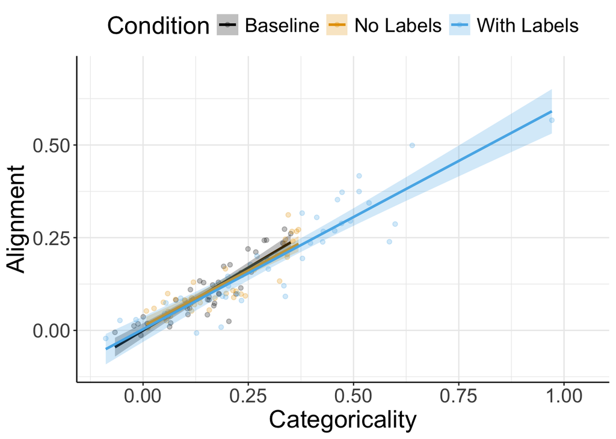

```r
ggplot(d_1_all, aes(y=mean_alignment, x=cat_min, color=Condition, fill=Condition)) +
  geom_point(alpha=.25) +
  geom_smooth(method="lm", alpha=.25) +
  theme_bw() +
  ylab("Alignment") +
  xlab("Categoricality") +
  scale_fill_manual(values=colors) +
  scale_color_manual(values=colors) +
  theme(text=element_text(size=20)) +
  theme(legend.position="top") +
    expand_limits(y=c(-.1,.7),x = c(-.1,1.05))+
  theme(panel.border = element_blank(), axis.line = element_line())
```

```r
ggsave("plots/CEL_1_alignment_controlled_by_categoricality_scatter.pdf")
```

# Study 2

```r
indiv_df_2 <- read.csv(file="data/CEL_2_indiv_data.tsv", header=T, sep="\t") %>%
    mutate(Condition = case_when(
        cond_numeric<0 ~ "Baseline",
        cond_numeric==0 ~ "No Labels",
        cond_numeric>0 ~ "With Labels"),
        exp="exp2")

pairwise_df_2 <- read.csv(file="data/CEL_2_pairwise_data.tsv", header=T, sep="\t")

#get alignment between pairs of participants for within category comparisons
pairwise_df_2_within <- read.csv(file="data/CEL_2_pairwise_within.tsv", header=T, sep="\t") %>%
    select(participant_a, participant_b, z_transformed_rank_r) %>%
    rename(mean_alignment_within = z_transformed_rank_r)

#get alignment between pairs of participants for within category comparisons
pairwise_df_2_between <- read.csv(file="data/CEL_2_pairwise_cross.tsv", header=T, sep="\t") %>%
    select(participant_a, participant_b, z_transformed_rank_r) %>%
    rename(mean_alignment_between = z_transformed_rank_r)

pairwise_df_2 <- left_join(pairwise_df_2,pairwise_df_2_within,
                                                     by=c("participant_a"="participant_a", "participant_b"="participant_b"))

pairwise_df_2 <- left_join(pairwise_df_2,pairwise_df_2_between,
                                                     by=c("participant_a"="participant_a", "participant_b"="participant_b"))
```

## Effect of condition on categoricality measured as log(between/within)

```r
indiv_df_2 %>% group_by(Condition) %>%
    summarize(Categoricality_mean = mean(log_cat_ratio),Categoricality_sd = sd(log_cat_ratio),n=n())
```

```
## # A tibble: 3 × 4
##   Condition   Categoricality_mean Categoricality_sd     n
##   <chr>                     <dbl>             <dbl> <int>
## 1 Baseline                  0.492             0.356    41
## 2 No Labels                 0.604             0.436    37
## 3 With Labels               0.664             0.379    44
```

```r
indiv_df_2 %>% lm(log_cat_ratio ~ relevel(as.factor(cond_numeric), ref='0'), data=.) %>% summary
```

```
##
## Call:
## lm(formula = log_cat_ratio ~ relevel(as.factor(cond_numeric),
##     ref = "0"), data = .)
##
## Residuals:
##      Min       1Q   Median       3Q      Max
## -0.67259 -0.29032 -0.09199  0.22548  1.29283
##
## Coefficients:
##                                               Estimate Std. Error t value
## (Intercept)                                    0.60360    0.06410   9.416
## relevel(as.factor(cond_numeric), ref = "0")-1 -0.11175    0.08842  -1.264
## relevel(as.factor(cond_numeric), ref = "0")1   0.06071    0.08698   0.698
##                                               Pr(>|t|)
## (Intercept)                                   4.53e-16 ***
## relevel(as.factor(cond_numeric), ref = "0")-1    0.209
## relevel(as.factor(cond_numeric), ref = "0")1     0.487
## ---
## Signif. codes:  0 '***' 0.001 '**' 0.01 '*' 0.05 '.' 0.1 ' ' 1
##
## Residual standard error: 0.3899 on 119 degrees of freedom
## Multiple R-squared:  0.03438,    Adjusted R-squared:  0.01815
## F-statistic: 2.119 on 2 and 119 DF,  p-value: 0.1247
```

```r
indiv_df_2 %>% lm(log_cat_ratio ~ relevel(as.factor(cond_numeric), ref='1'), data=.) %>% summary
```

```
##
## Call:
## lm(formula = log_cat_ratio ~ relevel(as.factor(cond_numeric),
##     ref = "1"), data = .)
##
## Residuals:
##      Min       1Q   Median       3Q      Max
## -0.67259 -0.29032 -0.09199  0.22548  1.29283
##
## Coefficients:
##                                               Estimate Std. Error t value
## (Intercept)                                    0.66431    0.05878  11.301
## relevel(as.factor(cond_numeric), ref = "1")-1 -0.17246    0.08464  -2.038
## relevel(as.factor(cond_numeric), ref = "1")0  -0.06071    0.08698  -0.698
##                                               Pr(>|t|)
## (Intercept)                                     <2e-16 ***
## relevel(as.factor(cond_numeric), ref = "1")-1   0.0438 *
## relevel(as.factor(cond_numeric), ref = "1")0    0.4865
## ---
## Signif. codes:  0 '***' 0.001 '**' 0.01 '*' 0.05 '.' 0.1 ' ' 1
##
## Residual standard error: 0.3899 on 119 degrees of freedom
## Multiple R-squared:  0.03438,    Adjusted R-squared:  0.01815
## F-statistic: 2.119 on 2 and 119 DF,  p-value: 0.1247
```

### Categoricality plot

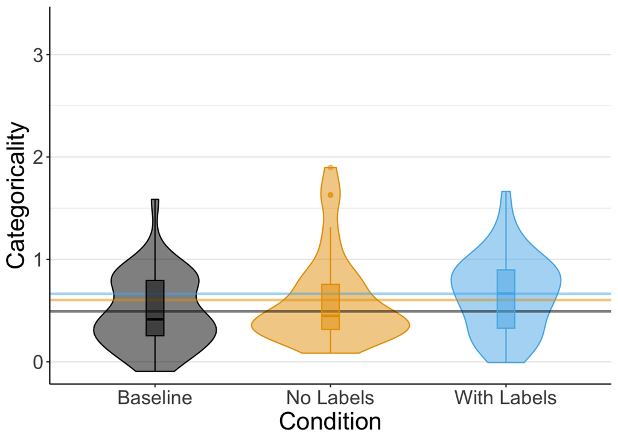

```r
means <- indiv_df_2 %>%
  group_by(Condition) %>%
  summarise(Categoricality = mean(log_cat_ratio))

ggplot(indiv_df_2, aes(y=log_cat_ratio, x=Condition, color=Condition, fill=Condition)) +
  geom_violin(alpha=.5) +
    scale_color_manual(values= colors) +
  scale_fill_manual(values= colors) +
  geom_hline(data=means, aes(yintercept=Categoricality, color=Condition), alpha=.5, size=1) +
  geom_boxplot(width=0.1, alpha=.5) +
  theme_bw() +
  scale_fill_manual(values=colors) +
  scale_color_manual(values=colors) +
  ylab("Categoricality") +
  theme(text=element_text(size=20)) +
  theme(legend.position="blank") +
    coord_cartesian(ylim=c(-.05,3.3))+
  theme(panel.grid.major.x = element_blank(), panel.grid.minor.x = element_blank()) +
  theme(panel.border = element_blank(), axis.line = element_line())
```

```r
ggsave("plots/CEL_2_categoricality_violin.pdf")
```

## Effect of condition on the number of clusters formed during free-sort

Number of clusters per condition

```r
indiv_df_2 %>%
  group_by(Condition) %>%
  summarise(Clusters = mean(n_clusters))
```

```
## # A tibble: 3 × 2
##   Condition   Clusters
##   <chr>          <dbl>
## 1 Baseline        3.32
## 2 No Labels       3.19
## 3 With Labels     2.84
```

## Label participants produce a similar number of clusters on average to the other 2 conditions

Poisson model wins (shown by likelihood ratio test to be nearly identical to the negative binomial model)

```r
nb_counts <- indiv_df_2 %>% MASS::glm.nb(formula=n_clusters ~ relevel(as.factor(cond_numeric), ref='1'), data=.)
poisson_counts <- indiv_df_2 %>% glm(formula=n_clusters ~ relevel(as.factor(cond_numeric), ref='1'), data=.,family=poisson)

pchisq(2 * (logLik(nb_counts) - logLik(poisson_counts)), df = 1, lower.tail = FALSE)
```

```
## 'log Lik.' 1 (df=4)
```

```r
summary(poisson_counts)
```

```
##
## Call:
## glm(formula = n_clusters ~ relevel(as.factor(cond_numeric), ref = "1"),
##     family = poisson, data = .)
##
## Coefficients:
##                                               Estimate Std. Error z value
## (Intercept)                                    1.04412    0.08944  11.674
## relevel(as.factor(cond_numeric), ref = "1")-1  0.15496    0.12391   1.251
## relevel(as.factor(cond_numeric), ref = "1")0   0.11564    0.12835   0.901
##                                               Pr(>|z|)
## (Intercept)                                     <2e-16 ***
## relevel(as.factor(cond_numeric), ref = "1")-1    0.211
## relevel(as.factor(cond_numeric), ref = "1")0     0.368
## ---
## Signif. codes:  0 '***' 0.001 '**' 0.01 '*' 0.05 '.' 0.1 ' ' 1
##
## (Dispersion parameter for poisson family taken to be 1)
##
##     Null deviance: 63.664  on 121  degrees of freedom
## Residual deviance: 61.982  on 119  degrees of freedom
## AIC: 428.36
##
## Number of Fisher Scoring iterations: 4
```

Label people are significantly more likely to produce 2-cluster sorts

```r
indiv_df_2 %>% group_by(Condition) %>%
    summarize(two_cluster_sorts = mean(I(n_clusters==2)))
```

```
## # A tibble: 3 × 2
##   Condition   two_cluster_sorts
##   <chr>                   <dbl>
## 1 Baseline                0.366
## 2 No Labels               0.351
## 3 With Labels             0.591
```

```r
indiv_df_2 %>% glm(I(n_clusters==2) ~ relevel(as.factor(cond_numeric), ref='1'), data=.,family=binomial) %>% summary
```

```
##
## Call:
## glm(formula = I(n_clusters == 2) ~ relevel(as.factor(cond_numeric),
##     ref = "1"), family = binomial, data = .)
##
## Coefficients:
##                                               Estimate Std. Error z value
## (Intercept)                                     0.3677     0.3066   1.199
## relevel(as.factor(cond_numeric), ref = "1")-1  -0.9178     0.4463  -2.057
## relevel(as.factor(cond_numeric), ref = "1")0   -0.9808     0.4611  -2.127
##                                               Pr(>|z|)
## (Intercept)                                     0.2304
## relevel(as.factor(cond_numeric), ref = "1")-1   0.0397 *
## relevel(as.factor(cond_numeric), ref = "1")0    0.0334 *
## ---
## Signif. codes:  0 '***' 0.001 '**' 0.01 '*' 0.05 '.' 0.1 ' ' 1
##
## (Dispersion parameter for binomial family taken to be 1)
##
##     Null deviance: 167.52  on 121  degrees of freedom
## Residual deviance: 161.36  on 119  degrees of freedom
## AIC: 167.36
##
## Number of Fisher Scoring iterations: 4
```

### Plot Number of clusters

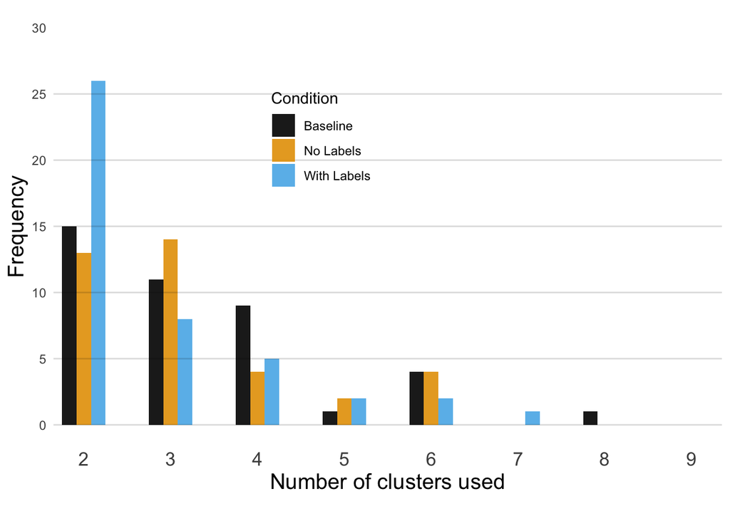

```r
ggplot(indiv_df_2, aes(x=n_clusters, fill=Condition)) +
  geom_histogram(alpha=0.9,position="dodge", binwidth=0.5)+
  scale_x_continuous(breaks = seq(1, 10, 1))+
  scale_y_continuous(breaks = seq(0, 30, 5))+
  labs(caption = "", size=20) +
  theme_minimal() +
  theme(panel.grid.major = element_blank()) +
  theme(panel.grid.minor = element_blank()) +
  geom_hline(yintercept = c(0,5,10,15,20,25), alpha = 0.15) +
  scale_fill_manual(values=colors) +
  scale_color_manual(values=colors) +
  ylab("Frequency") +
  xlab("Number of clusters used") +
    coord_cartesian(ylim=c(0,30),xlim=c(2,9))+
  theme(axis.text.x = element_text(size=13),
       axis.title.y = element_text(size=15),
       axis.title.x = element_text(size=15))+
  theme(legend.position = c(.4, .7))
```

```r
ggsave("plots/CEL_2_n_clusters_histogram.pdf")
```

## Effect of condition on alignment (aggregated by participant)

Alignment significantly higher in with labels, compared with no labels and baseline

```r
pairwise_df_2 <- pairwise_df_2 %>%
    mutate(
                cat_max = pmax(cat_diff_log_ratio_a, cat_diff_log_ratio_b),
                cat_abs_diff = abs(cat_diff_log_ratio_a-cat_diff_log_ratio_b),
                cat_min = pmin(cat_diff_log_ratio_a, cat_diff_log_ratio_b),
                 cluster_min = pmin(pp_a_n_clusters, pp_b_n_clusters),
                 cluster_max = pmax(pp_a_n_clusters, pp_b_n_clusters),
                 cluster_abs_diff = abs(pp_a_n_clusters-pp_b_n_clusters)
                 )


d_2a <- pairwise_df_2 %>%
  group_by(cond_numeric,Condition,participant_a) %>%
  summarize_if(is.numeric,mean,na.rm=TRUE) %>%
  rename(participant = participant_a)
d_2b <- pairwise_df_2 %>%
  group_by(cond_numeric,Condition,participant_b) %>%
  summarize_if(is.numeric,mean,na.rm=TRUE) %>%
  rename(participant = participant_b)
d_2_all <- rbind(d_2a,d_2b) %>%
  group_by(cond_numeric,Condition,participant) %>%
  summarize_if(is.numeric,mean,na.rm=TRUE) %>%
    rename(mean_alignment = z_transformed_rank_r)

#merge in individual categoricality
d_2_all <- d_2_all %>% left_join(select(indiv_df_2,participant,log_cat_ratio))


#residualize categoricality from alignment for later analysis
d_2_all$mean_alignment_adj <- resid(lm(mean_alignment ~ cat_min, data=d_2_all))
d_2_all$exp <- "exp2"
```

## Alignment analyses

```r
means <- d_2_all %>%
  group_by(Condition) %>%
  summarise(Alignment = mean(mean_alignment),Alignment_sd=sd(mean_alignment))

means
```

```
## # A tibble: 3 × 3
##   Condition   Alignment Alignment_sd
##   <chr>           <dbl>        <dbl>
## 1 Baseline        0.207        0.118
## 2 No Labels       0.272        0.112
## 3 With Labels     0.345        0.168
```

```r
lm(formula=mean_alignment ~ relevel(as.factor(cond_numeric), ref='1'), data=d_2_all) %>% summary
```

```
##
## Call:
## lm(formula = mean_alignment ~ relevel(as.factor(cond_numeric),
##     ref = "1"), data = d_2_all)
##
## Residuals:
##      Min       1Q   Median       3Q      Max
## -0.33389 -0.09903  0.01155  0.10980  0.31374
##
## Coefficients:
##                                               Estimate Std. Error t value
## (Intercept)                                    0.34453    0.02059  16.730
## relevel(as.factor(cond_numeric), ref = "1")-1 -0.13723    0.02965  -4.628
## relevel(as.factor(cond_numeric), ref = "1")0  -0.07216    0.03047  -2.368
##                                               Pr(>|t|)
## (Intercept)                                    < 2e-16 ***
## relevel(as.factor(cond_numeric), ref = "1")-1 9.48e-06 ***
## relevel(as.factor(cond_numeric), ref = "1")0    0.0195 *
## ---
## Signif. codes:  0 '***' 0.001 '**' 0.01 '*' 0.05 '.' 0.1 ' ' 1
##
## Residual standard error: 0.1366 on 119 degrees of freedom
## Multiple R-squared:  0.1528, Adjusted R-squared:  0.1386
## F-statistic: 10.73 on 2 and 119 DF,  p-value: 5.178e-05
```

```r
lm(formula=mean_alignment ~ relevel(as.factor(cond_numeric), ref='0'), data=d_2_all) %>% summary
```

```
##
## Call:
## lm(formula = mean_alignment ~ relevel(as.factor(cond_numeric),
##     ref = "0"), data = d_2_all)
##
## Residuals:
##      Min       1Q   Median       3Q      Max
## -0.33389 -0.09903  0.01155  0.10980  0.31374
##
## Coefficients:
##                                               Estimate Std. Error t value
## (Intercept)                                    0.27237    0.02246  12.128
## relevel(as.factor(cond_numeric), ref = "0")-1 -0.06507    0.03097  -2.101
## relevel(as.factor(cond_numeric), ref = "0")1   0.07216    0.03047   2.368
##                                               Pr(>|t|)
## (Intercept)                                     <2e-16 ***
## relevel(as.factor(cond_numeric), ref = "0")-1   0.0378 *
## relevel(as.factor(cond_numeric), ref = "0")1    0.0195 *
## ---
## Signif. codes:  0 '***' 0.001 '**' 0.01 '*' 0.05 '.' 0.1 ' ' 1
##
## Residual standard error: 0.1366 on 119 degrees of freedom
## Multiple R-squared:  0.1528, Adjusted R-squared:  0.1386
## F-statistic: 10.73 on 2 and 119 DF,  p-value: 5.178e-05
```

### Alignment plot

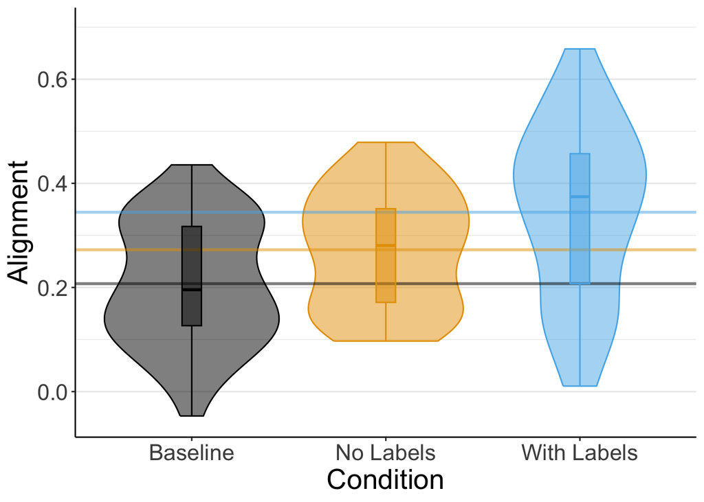

```r
ggplot(d_2_all, aes(y=mean_alignment, x=Condition, color=Condition, fill=Condition)) +
  geom_violin(alpha=.5) +
  geom_hline(data=means, aes(yintercept=Alignment, col=Condition), alpha=.5, size=1) +
  geom_boxplot(width=0.1, alpha=.5) +
  theme_bw() +
  scale_fill_manual(values=colors) +
  scale_color_manual(values=colors) +
  ylab("Alignment") +
  theme(text=element_text(size=20)) +
  theme(legend.position="blank") +
    coord_cartesian(ylim=c(-.05,.7))+
  theme(panel.grid.major.x = element_blank(), panel.grid.minor.x = element_blank()) +
  theme(panel.border = element_blank(), axis.line = element_line())
```

```r
ggsave("plots/CEL_2_alignment_violin.pdf")
```

For supplementary materials (Fig 3S)

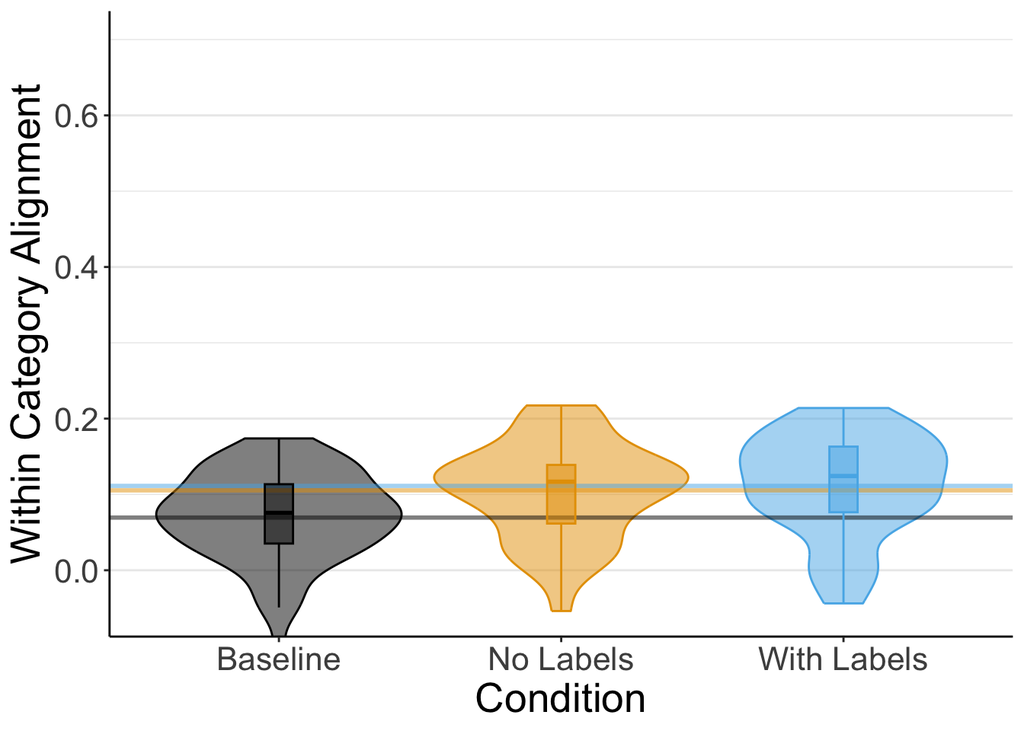

```r
means <- d_2_all %>%
  group_by(Condition) %>%
  summarise(Alignment = mean(mean_alignment_within),Alignment_sd=sd(mean_alignment_within))

ggplot(d_2_all, aes(y=mean_alignment_within, x=Condition, color=Condition, fill=Condition)) +
  geom_violin(alpha=.5) +
  geom_hline(data=means, aes(yintercept=Alignment, col=Condition), alpha=.5, size=1) +
  geom_boxplot(width=0.1, alpha=.5) +
  theme_bw() +
  scale_fill_manual(values=colors) +
  scale_color_manual(values=colors) +
  ylab("Within Category Alignment") +
  theme(text=element_text(size=20)) +
  theme(legend.position="blank") +
    coord_cartesian(ylim=c(-.05,.7))+
  theme(panel.grid.major.x = element_blank(), panel.grid.minor.x = element_blank()) +
  theme(panel.border = element_blank(), axis.line = element_line())
```

```r
ggsave("plots/CEL_2_alignment_within_violin.pdf")
```

For supplementary materials (Fig 3S)

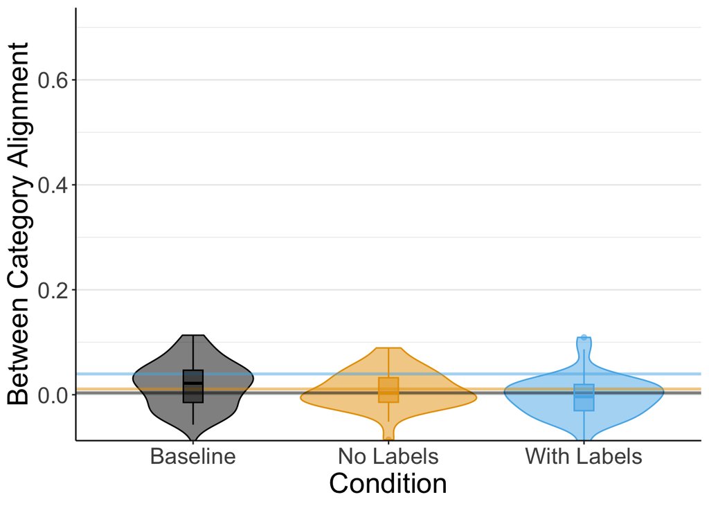

```r
means <- d_2_all %>%
  group_by(Condition) %>%
  summarise(Alignment = mean(mean_alignment_between),Alignment_sd=sd(mean_alignment_between))


ggplot(d_1_all, aes(y=mean_alignment_between, x=Condition, color=Condition, fill=Condition)) +
  geom_violin(alpha=.5) +
  geom_hline(data=means, aes(yintercept=Alignment, col=Condition), alpha=.5, size=1) +
  geom_boxplot(width=0.1, alpha=.5) +
  theme_bw() +
  scale_fill_manual(values=colors) +
  scale_color_manual(values=colors) +
  ylab("Between Category Alignment") +
  theme(text=element_text(size=20)) +
  theme(legend.position="blank") +
    coord_cartesian(ylim=c(-.05,.7))+
  theme(panel.grid.major.x = element_blank(), panel.grid.minor.x = element_blank()) +
  theme(panel.border = element_blank(), axis.line = element_line())
```

```r
ggsave("plots/CEL_2_alignment_between_violin.pdf")
```

## Correlation between alignment and different measures of pair-wise categoricality

Again, minimum pairwise categoricality is most correlated with alignment

```r
d_2_all %>% ungroup %>%
    select(mean_alignment,cat_min,cat_max, cat_abs_diff) %>%
    correlate
```

```
## Correlation computed with
## • Method: 'pearson'
## • Missing treated using: 'pairwise.complete.obs'
```

```
## # A tibble: 4 × 5
##   term           mean_alignment cat_min cat_max cat_abs_diff
##   <chr>                   <dbl>   <dbl>   <dbl>        <dbl>
## 1 mean_alignment         NA      0.945    0.713       0.130
## 2 cat_min                 0.945 NA        0.723       0.0926
## 3 cat_max                 0.713  0.723   NA           0.754
## 4 cat_abs_diff            0.130  0.0926   0.754      NA
```

## Effect of condition on alignment controlling for minimum categoricality by pair

```r
d_2_all %>% lm(formula=mean_alignment ~ cat_min+relevel(as.factor(cond_numeric), ref='1'), data=.) %>% summary
```

```
##
## Call:
## lm(formula = mean_alignment ~ cat_min + relevel(as.factor(cond_numeric),
##     ref = "1"), data = .)
##
## Residuals:
##       Min        1Q    Median        3Q       Max
## -0.160434 -0.025690 -0.005498  0.038249  0.091486
##
## Coefficients:
##                                                Estimate Std. Error t value
## (Intercept)                                    0.002266   0.013749   0.165
## cat_min                                        0.775148   0.026520  29.229
## relevel(as.factor(cond_numeric), ref = "1")-1 -0.013756   0.011200  -1.228
## relevel(as.factor(cond_numeric), ref = "1")0  -0.024866   0.010782  -2.306
##                                               Pr(>|t|)
## (Intercept)                                     0.8694
## cat_min                                         <2e-16 ***
## relevel(as.factor(cond_numeric), ref = "1")-1   0.2218
## relevel(as.factor(cond_numeric), ref = "1")0    0.0228 *
## ---
## Signif. codes:  0 '***' 0.001 '**' 0.01 '*' 0.05 '.' 0.1 ' ' 1
##
## Residual standard error: 0.04779 on 118 degrees of freedom
## Multiple R-squared:  0.8972, Adjusted R-squared:  0.8946
## F-statistic: 343.2 on 3 and 118 DF,  p-value: < 2.2e-16
```

```r
d_2_all %>% lm(formula=mean_alignment ~ cat_min+relevel(as.factor(cond_numeric), ref='0'), data=.) %>% summary
```

```
##
## Call:
## lm(formula = mean_alignment ~ cat_min + relevel(as.factor(cond_numeric),
##     ref = "0"), data = .)
##
## Residuals:
##       Min        1Q    Median        3Q       Max
## -0.160434 -0.025690 -0.005498  0.038249  0.091486
##
## Coefficients:
##                                               Estimate Std. Error t value
## (Intercept)                                   -0.02260    0.01279  -1.767
## cat_min                                        0.77515    0.02652  29.229
## relevel(as.factor(cond_numeric), ref = "0")-1  0.01111    0.01115   0.997
## relevel(as.factor(cond_numeric), ref = "0")1   0.02487    0.01078   2.306
##                                               Pr(>|t|)
## (Intercept)                                     0.0798 .
## cat_min                                         <2e-16 ***
## relevel(as.factor(cond_numeric), ref = "0")-1   0.3209
## relevel(as.factor(cond_numeric), ref = "0")1    0.0228 *
## ---
## Signif. codes:  0 '***' 0.001 '**' 0.01 '*' 0.05 '.' 0.1 ' ' 1
##
## Residual standard error: 0.04779 on 118 degrees of freedom
## Multiple R-squared:  0.8972, Adjusted R-squared:  0.8946
## F-statistic: 343.2 on 3 and 118 DF,  p-value: < 2.2e-16
```

### Plot Exp2 alignment as a function of categoricality

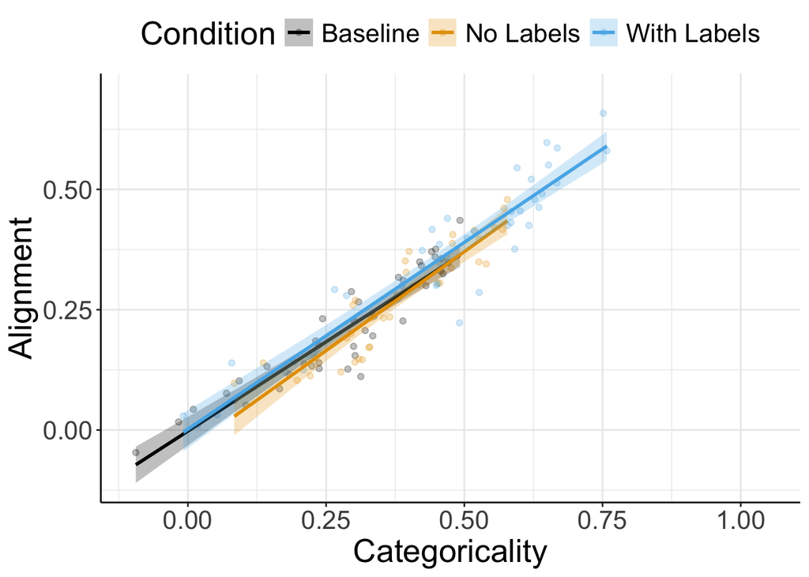

```r
ggplot(d_2_all, aes(y=mean_alignment, x=cat_min, color=Condition, fill=Condition)) +
  geom_point(alpha=.25) +
  geom_smooth(method="lm", alpha=.25) +
  theme_bw() +
  ylab("Alignment") +
  xlab("Categoricality") +
  scale_fill_manual(values=colors) +
  scale_color_manual(values=colors) +
  theme(text=element_text(size=20)) +
  theme(legend.position="top") +
    expand_limits(y=c(-.1,.7),x = c(-.1,1.05))+
  theme(panel.border = element_blank(), axis.line = element_line())
```

```r
ggsave("plots/CEL_2_alignment_controlled_by_categoricality_scatter.pdf")
```

## Effect of condition on alignment controlling for cluster nums

```r
d_2_all %>%  with(cor.test(mean_alignment,cluster_min))
```

```
##
##  Pearson's product-moment correlation
##
## data:  mean_alignment and cluster_min
## t = -4.3942, df = 120, p-value = 2.414e-05
## alternative hypothesis: true correlation is not equal to 0
## 95 percent confidence interval:
##  -0.5159161 -0.2083246
## sample estimates:
##        cor
## -0.3722985
```

```r
d_2_all %>%  with(cor.test(mean_alignment,cluster_max))
```

```
##
##  Pearson's product-moment correlation
##
## data:  mean_alignment and cluster_max
## t = -5.0621, df = 120, p-value = 1.514e-06
## alternative hypothesis: true correlation is not equal to 0
## 95 percent confidence interval:
##  -0.5557957 -0.2611943
## sample estimates:
##        cor
## -0.4194788
```

```r
d_2_all %>%  with(cor.test(mean_alignment,cluster_abs_diff))
```

```
##
##  Pearson's product-moment correlation
##
## data:  mean_alignment and cluster_abs_diff
## t = -4.2418, df = 120, p-value = 4.387e-05
## alternative hypothesis: true correlation is not equal to 0
## 95 percent confidence interval:
##  -0.5063526 -0.1959077
## sample estimates:
##        cor
## -0.3610936
```

```r
d_2_all %>%  lm(mean_alignment~cat_min+cluster_min+relevel(as.factor(cond_numeric), ref='1'), data=.) %>% summary
```

```
##
## Call:
## lm(formula = mean_alignment ~ cat_min + cluster_min + relevel(as.factor(cond_numeric),
##     ref = "1"), data = .)
##
## Residuals:
##       Min        1Q    Median        3Q       Max
## -0.158720 -0.025862 -0.005906  0.038068  0.091317
##
## Coefficients:
##                                                Estimate Std. Error t value
## (Intercept)                                    0.010028   0.031536   0.318
## cat_min                                        0.772928   0.027832  27.772
## cluster_min                                   -0.003076   0.011237  -0.274
## relevel(as.factor(cond_numeric), ref = "1")-1 -0.013026   0.011556  -1.127
## relevel(as.factor(cond_numeric), ref = "1")0  -0.023854   0.011438  -2.085
##                                               Pr(>|t|)
## (Intercept)                                     0.7511
## cat_min                                         <2e-16 ***
## cluster_min                                     0.7848
## relevel(as.factor(cond_numeric), ref = "1")-1   0.2620
## relevel(as.factor(cond_numeric), ref = "1")0    0.0392 *
## ---
## Signif. codes:  0 '***' 0.001 '**' 0.01 '*' 0.05 '.' 0.1 ' ' 1
##
## Residual standard error: 0.04798 on 117 degrees of freedom
## Multiple R-squared:  0.8973, Adjusted R-squared:  0.8937
## F-statistic: 255.4 on 4 and 117 DF,  p-value: < 2.2e-16
```

```r
d_2_all %>%  lm(mean_alignment~cat_min+cluster_max+relevel(as.factor(cond_numeric), ref='1'), data=.) %>% summary
```

```
##
## Call:
## lm(formula = mean_alignment ~ cat_min + cluster_max + relevel(as.factor(cond_numeric),
##     ref = "1"), data = .)
##
## Residuals:
##       Min        1Q    Median        3Q       Max
## -0.148478 -0.026554 -0.003902  0.038558  0.089126
##
## Coefficients:
##                                                Estimate Std. Error t value
## (Intercept)                                    0.021150   0.024595   0.860
## cat_min                                        0.766331   0.028192  27.183
## cluster_max                                   -0.004405   0.004756  -0.926
## relevel(as.factor(cond_numeric), ref = "1")-1 -0.011970   0.011372  -1.053
## relevel(as.factor(cond_numeric), ref = "1")0  -0.023358   0.010910  -2.141
##                                               Pr(>|t|)
## (Intercept)                                     0.3916
## cat_min                                         <2e-16 ***
## cluster_max                                     0.3562
## relevel(as.factor(cond_numeric), ref = "1")-1   0.2947
## relevel(as.factor(cond_numeric), ref = "1")0    0.0344 *
## ---
## Signif. codes:  0 '***' 0.001 '**' 0.01 '*' 0.05 '.' 0.1 ' ' 1
##
## Residual standard error: 0.04782 on 117 degrees of freedom
## Multiple R-squared:  0.8979, Adjusted R-squared:  0.8944
## F-statistic: 257.3 on 4 and 117 DF,  p-value: < 2.2e-16
```

```r
d_2_all %>%  lm(mean_alignment~cat_min+cluster_abs_diff+relevel(as.factor(cond_numeric), ref='1'), data=.) %>% summary
```

```
##
## Call:
## lm(formula = mean_alignment ~ cat_min + cluster_abs_diff + relevel(as.factor(cond_numeric),
##     ref = "1"), data = .)
##
## Residuals:
##       Min        1Q    Median        3Q       Max
## -0.145349 -0.026811 -0.003629  0.038101  0.088123
##
## Coefficients:
##                                                Estimate Std. Error t value
## (Intercept)                                    0.014598   0.017779   0.821
## cat_min                                        0.766195   0.027736  27.624
## cluster_abs_diff                              -0.006993   0.006400  -1.093
## relevel(as.factor(cond_numeric), ref = "1")-1 -0.012581   0.011243  -1.119
## relevel(as.factor(cond_numeric), ref = "1")0  -0.024772   0.010773  -2.299
##                                               Pr(>|t|)
## (Intercept)                                     0.4133
## cat_min                                         <2e-16 ***
## cluster_abs_diff                                0.2768
## relevel(as.factor(cond_numeric), ref = "1")-1   0.2654
## relevel(as.factor(cond_numeric), ref = "1")0    0.0233 *
## ---
## Signif. codes:  0 '***' 0.001 '**' 0.01 '*' 0.05 '.' 0.1 ' ' 1
##
## Residual standard error: 0.04775 on 117 degrees of freedom
## Multiple R-squared:  0.8982, Adjusted R-squared:  0.8947
## F-statistic: 258.2 on 4 and 117 DF,  p-value: < 2.2e-16
```